# Homework 5

Ericka Smith

10/27/2020

## Problem 1

#### Part A

load data:

```r
frogs <- data.frame(
  num_toes_removed = c(rep(1, 4), rep(2, 51), rep(3, 150), rep(4, 245), rep(5, 190), rep(6, 80),
                       rep(7, 12), 8),
  size = as.factor(c(rep("less",44), rep("greater", 11), rep("less", 120), rep("greater", 30),
                     rep("less", 180), rep("greater", 65), rep("less", 120), rep("greater", 70),
                     rep("less", 40), rep("greater", 40), rep("less", 4), rep("greater", 9))),
  recaptured = as.factor(c(rep("y", 3), "n", rep("y", 26), rep("n", 14), rep("y", 7),
                           rep("n",4), rep("y", 80), rep("n", 40), rep("y", 9), rep("n",21),
                           rep("y", 110), rep('n', 70), rep("y", 17), rep("n", 48),
                           rep("y", 68), rep("n", 52), rep("y", 17), rep("n", 53),
                           rep("y", 20),rep("n", 20), rep("y", 9), rep("n", 31), "y",
                           rep("n", 3), "y", rep("n",8))))
```

fit model:

```r
fit <- glm(recaptured ~size, data=frogs, family=binomial)
summary(fit)
```

```
##
## Call:
## glm(formula = recaptured ~ size, family = binomial, data = frogs)
##
## Deviance Residuals:
##    Min      1Q  Median      3Q     Max
## -1.365  -1.365   1.000   1.000   1.626
##
## Coefficients:
##             Estimate Std. Error z value Pr(>|z|)
## (Intercept)  -1.0116     0.1508  -6.710 1.94e-11 ***
## sizeless      1.4434     0.1760   8.201 2.38e-16 ***
## ---
## Signif. codes:  0 '***' 0.001 '**' 0.01 '*' 0.05 '.' 0.1 ' ' 1
##
## (Dispersion parameter for binomial family taken to be 1)
##
##     Null deviance: 1016.14  on 732  degrees of freedom
## Residual deviance:  942.06  on 731  degrees of freedom
## AIC: 946.06
##
## Number of Fisher Scoring iterations: 4
```

Based on the output there is an effect of size on return rate. For the coefficient for size, $p=2.38*10^{-16}$, which is significant at $\alpha=0.05$

#### Part B

fit model:

```r
fitb <- glm(recaptured ~ num_toes_removed, data=frogs, family=binomial)
summary(fitb)
```

```
##
## Call:
## glm(formula = recaptured ~ num_toes_removed, family = binomial,
##     data = frogs)
##
## Deviance Residuals:
##     Min       1Q   Median       3Q      Max
## -1.6344  -1.2046   0.7812   1.1505   1.5769
##
## Coefficients:
##                  Estimate Std. Error z value Pr(>|z|)
## (Intercept)       1.35275    0.28624   4.726 2.29e-06 ***
## num_toes_removed -0.32225    0.06619  -4.868 1.13e-06 ***
## ---
## Signif. codes:  0 '***' 0.001 '**' 0.01 '*' 0.05 '.' 0.1 ' ' 1
##
## (Dispersion parameter for binomial family taken to be 1)
##
##     Null deviance: 1016.14  on 732  degrees of freedom
## Residual deviance:  991.32  on 731  degrees of freedom
## AIC: 995.32
##
## Number of Fisher Scoring iterations: 4
```

Based on our model output there is an effect of toe clipping. The coefficient for number of toes removed is significant at $\alpha=0.05$, with $p=1.13*10^{-6}$

In order to estimate and interpret this I consider the coefficient itself. The estimate for the coefficient is -0.32225, which can be interpreted as the expected change in log odds for a one-unit increase in number of toes removed. The odds ratio then can be calculated by exponentiating this value to get $0.724517$, and taking $1-0.724517=0.275483\approx27.5\%$, which means that **we expect to see about 27.5% decrease in the odds of recapture for each additional toe clipped.**

#### Part C

To fit this model to the data set I will have $\beta_0=log(R(0))$ as my intercept and $\beta_1=log(1+m)$ as a coefficient for $n$ the covariate.

#### Part D

First change “y”s and “n”s to 0s and 1s

```r
frogs01 <- frogs %>%
  mutate(recaptured = recode(recaptured,
                             "y"="1",
                             "n"="0"))
```

Now fit the model

```r
fitd <- glm(as.integer(recaptured) ~ num_toes_removed, data=frogs01, family=poisson(link="log"))
summary(fitd)
```

```
##
## Call:
## glm(formula = as.integer(recaptured) ~ num_toes_removed, family = poisson(link = "log"),
##     data = frogs01)
##
## Deviance Residuals:
##     Min       1Q   Median       3Q      Max
## -0.6297  -0.4446   0.1706   0.3773   0.5740
##
## Coefficients:
##                  Estimate Std. Error z value Pr(>|z|)
## (Intercept)       0.62204    0.11001   5.655 1.56e-08 ***
## num_toes_removed -0.05203    0.02580  -2.017   0.0437 *
## ---
## Signif. codes:  0 '***' 0.001 '**' 0.01 '*' 0.05 '.' 0.1 ' ' 1
##
## (Dispersion parameter for poisson family taken to be 1)
##
##     Null deviance: 124.48  on 732  degrees of freedom
## Residual deviance: 120.41  on 731  degrees of freedom
## AIC: 1816.2
##
## Number of Fisher Scoring iterations: 4
```

## Problem 2

#### Part A

Load data:

```r
blood <- data.frame(plasma_pct = rep(c(.05, .10, .15, .20,.30, .40, .60, .80, 1), 2),
                       Medicine = as.factor(rep(c("A", "B"), each = 9)),
                       clot_time = c(118, 58, 42, 35, 27, 25, 21, 19, 18,69, 35, 26, 21, 18, 16, 13, 12, 12))
```

Create Plots:

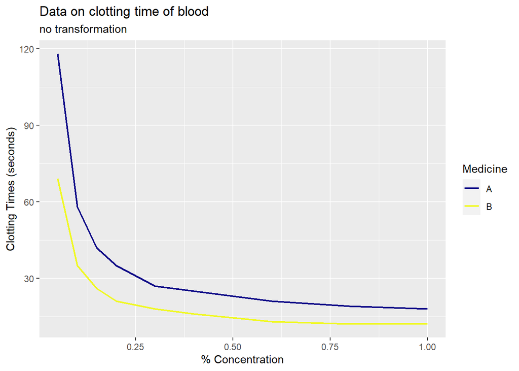

```r
ggplot(data=blood)+
  geom_line(aes(x=plasma_pct, y=clot_time, color=Medicine), size=0.75)+
  theme_grey()+
  labs(title="Data on clotting time of blood",
       subtitle = "no transformation")+
  xlab("% Concentration")+
  ylab("Clotting Times (seconds)")+
  scale_color_viridis(discrete = TRUE, option="plasma")
```

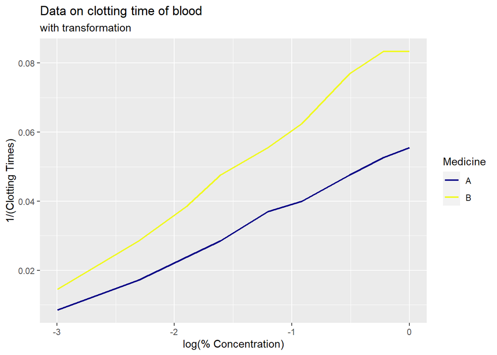

```r
ggplot(data=blood)+
  geom_line(aes(x=log(plasma_pct), y=(1/clot_time), color=Medicine), size=0.75)+
  theme_grey()+
  labs(title="Data on clotting time of blood",
       subtitle = "with transformation")+
  xlab("log(% Concentration)")+
  ylab("1/(Clotting Times)")+
  scale_color_viridis(discrete = TRUE, option = "plasma")
```

In the plot with no transformation I see that Medicine B has lower clotting times for all of the 9 percentage concentrations.

In the plot with both percentage concentration and clotting times transformed I see that Medicine B changes more steeply than Medicine A does between the different concentrations.

#### Part B

Update data:

```r
blood_b <- blood %>%
  mutate(yinv = (1/clot_time),
         logpct = log(plasma_pct))
```

Fit model:

```r
fit2b <- glm(yinv ~ logpct*Medicine-1, family = Gamma(link = "inverse"), data = blood_b)
summary(fit2b)
```

```
##
## Call:
## glm(formula = yinv ~ logpct * Medicine - 1, family = Gamma(link = "inverse"),
##     data = blood_b)
##
## Deviance Residuals:
##      Min        1Q    Median        3Q       Max
## -0.56521  -0.10273   0.07791   0.15479   0.24602
##
## Coefficients:
##                  Estimate Std. Error t value Pr(>|t|)
## logpct            -16.205      2.921  -5.548 7.18e-05 ***
## MedicineA          14.688      2.585   5.683 5.65e-05 ***
## MedicineB           9.618      1.672   5.754 4.99e-05 ***
## logpct:MedicineB    6.498      3.445   1.886   0.0802 .
## ---
## Signif. codes:  0 '***' 0.001 '**' 0.01 '*' 0.05 '.' 0.1 ' ' 1
##
## (Dispersion parameter for Gamma family taken to be 0.05485759)
##
##     Null deviance:     NaN  on 18  degrees of freedom
## Residual deviance: 0.94007  on 14  degrees of freedom
## AIC: -109.52
##
## Number of Fisher Scoring iterations: 4
```

Residual Analysis:

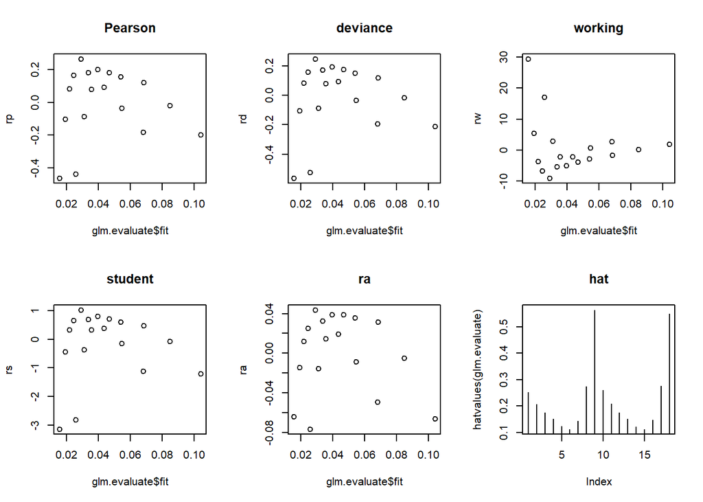

```r
glm.evaluate=fit2b

rp=resid(glm.evaluate, "pearson")
rd=resid(glm.evaluate, "deviance")
rw=resid(glm.evaluate, "working")
rs=rstudent(glm.evaluate)
ra=3*(glm.evaluate$y^{2/3}-glm.evaluate$fit^{2/3})/glm.evaluate$fit^{1/6}/2

par(mfrow=c(2,3))
plot(glm.evaluate$fit,rp, main="Pearson")
plot(glm.evaluate$fit,rd, main = "deviance")
plot(glm.evaluate$fit,rw, main="working")
plot(glm.evaluate$fit,rs, main="student")
plot(glm.evaluate$fit,ra, main="ra")
plot(hatvalues(glm.evaluate), type="h", main="hat")
```

Based on the residual analysis plots it seems that the proposed model is a decent fit. The deviance residuals are small and that indicates a good fit. The working residuals are a bit concerning but I still think it’s overall a good fit.